# Técnicas Clássicas de Reconhecimento de Padrões (2020/01)

## Exercício 02 - Classificação da Base de Dados de Leucemia

*Reprodução dos Resultados Apresentados por Golub et al 1999*

**Aluno: Ramon Gomes Durães de Oliveira (2019720188)**

## Pré-processamento de dados

### Carregando os Dados

Foram utilizados os dados disponibilizados pela plataforma Kaggle.

- "class_df": contém as classes de cada observação
- "train_df": contém as observações do conjunto de treinamento
- "test_df": contém as observações do conjunto de teste

```python
import numpy as np
import pandas as pd
import matplotlib.pyplot as plt

class_df = pd.read_csv('./data/actual.csv')
train_df = pd.read_csv('./data/data_set_ALL_AML_train.csv')
test_df = pd.read_csv('./data/data_set_ALL_AML_independent.csv')
```

### Limpando os Dados

Nesta seção os dados são limpados, removendo colunas desnecessárias e transpondo os dados. Além disso, a classe de cada observação é extraída do conjunto de dados "class_df" e integrada aos dados de treinamento e teste. As classes do conjunto de teste serão utilizadas apenas para avaliação da classificação. Os conjuntos de dados resultantes possuem 38 observações de treinamento e 34 de teste, como no artigo do Golub. Há dados para 7129 genes.

```python
valid_columns = [col for col in train_df.columns if "call" not in col]
train_df = train_df[valid_columns]
train_df = train_df.T
train_df = train_df.drop(['Gene Description','Gene Accession Number'],axis=0)
train_df.index = pd.to_numeric(train_df.index)
train_df.sort_index(inplace=True)
class_dict = {'AML':0,'ALL':1}
train_df['class'] = class_df[:38]['cancer'].replace(class_dict).values
train_df.head()
```

|  | 0 | 1 | 2 | 3 | 4 | 5 | 6 | 7 | 8 | 9 | ... | 7120 | 7121 | 7122 | 7123 | 7124 | 7125 | 7126 | 7127 | 7128 | class |
| --- | --- | --- | --- | --- | --- | --- | --- | --- | --- | --- | --- | --- | --- | --- | --- | --- | --- | --- | --- | --- | --- |
| 1 | -214 | -153 | -58 | 88 | -295 | -558 | 199 | -176 | 252 | 206 | ... | 511 | -125 | 389 | -37 | 793 | 329 | 36 | 191 | -37 | 1 |
| 2 | -139 | -73 | -1 | 283 | -264 | -400 | -330 | -168 | 101 | 74 | ... | 837 | -36 | 442 | -17 | 782 | 295 | 11 | 76 | -14 | 1 |
| 3 | -76 | -49 | -307 | 309 | -376 | -650 | 33 | -367 | 206 | -215 | ... | 1199 | 33 | 168 | 52 | 1138 | 777 | 41 | 228 | -41 | 1 |
| 4 | -135 | -114 | 265 | 12 | -419 | -585 | 158 | -253 | 49 | 31 | ... | 835 | 218 | 174 | -110 | 627 | 170 | -50 | 126 | -91 | 1 |
| 5 | -106 | -125 | -76 | 168 | -230 | -284 | 4 | -122 | 70 | 252 | ... | 649 | 57 | 504 | -26 | 250 | 314 | 14 | 56 | -25 | 1 |

5 rows × 7130 columns

Dados de teste:

```python
valid_columns = [col for col in test_df.columns if "call" not in col]
test_df = test_df[valid_columns]
test_df = test_df.T
test_df = test_df.drop(['Gene Description','Gene Accession Number'],axis=0)
test_df.index = pd.to_numeric(test_df.index)
test_df.sort_index(inplace=True)
test_df['class'] = class_df[38:]['cancer'].replace(class_dict).values
test_df.head()
```

|  | 0 | 1 | 2 | 3 | 4 | 5 | 6 | 7 | 8 | 9 | ... | 7120 | 7121 | 7122 | 7123 | 7124 | 7125 | 7126 | 7127 | 7128 | class |
| --- | --- | --- | --- | --- | --- | --- | --- | --- | --- | --- | --- | --- | --- | --- | --- | --- | --- | --- | --- | --- | --- |
| 39 | -342 | -200 | 41 | 328 | -224 | -427 | -656 | -292 | 137 | -144 | ... | 1023 | 67 | 214 | -135 | 1074 | 475 | 48 | 168 | -70 | 1 |
| 40 | -87 | -248 | 262 | 295 | -226 | -493 | 367 | -452 | 194 | 162 | ... | 529 | -295 | 352 | -67 | 67 | 263 | -33 | -33 | -21 | 1 |
| 41 | -62 | -23 | -7 | 142 | -233 | -284 | -167 | -97 | -12 | -70 | ... | 383 | 46 | 104 | 15 | 245 | 164 | 84 | 100 | -18 | 1 |
| 42 | 22 | -153 | 17 | 276 | -211 | -250 | 55 | -141 | 0 | 500 | ... | 399 | 16 | 558 | 24 | 893 | 297 | 6 | 1971 | -42 | 1 |
| 43 | 86 | -36 | -141 | 252 | -201 | -384 | -420 | -197 | -60 | -468 | ... | 91 | -84 | 615 | -52 | 1235 | 9 | 7 | 1545 | -81 | 1 |

5 rows × 7130 columns

## Seleção e Classificação

### Seleção de Genes Relevantes

Para selecionar um subconjunto de genes relevantes e efetivos para a classificação, no artigo os autores criam dois genes simbólicos com o grau de expressão máximo para uma das classes e mínimo para a outra.

Nos dados utilizados pelo autor, os valores máximos e mínimos correspondiam ao range de 0 a 1. Neste conjunto de dados este não é o caso. Logo, será utilizado o máximo e mínimo amostral do nível de expressão de cada gene.

No artigo, a correlação de um gene com a classificação desejada é calculada utilizando a fórmula:

$P(g,c) = [\mu_1(g) - \mu_2(g)]/[\sigma_1(g)+\sigma_2(g)]$

Na qual:

- g é um gene
- $\mu$ é a média amostral
- $\sigma$ é o desvio padrão amostral
- os números subscritos ($\mu_1$,$\mu_2$) indicam as classes 1 e 2.

Aqui, busca-se por valores altos de $|P(g,c)|$. Essa medida será calculada para todos os genes e eles serão ordenados de acordo com seu valor absoluto:

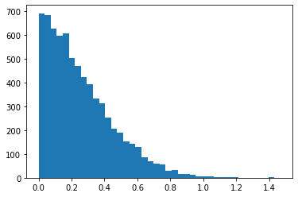

```python
mu1 = train_df[train_df['class']==0].iloc[:,:-1].mean()
sigma1 = train_df[train_df['class']==0].iloc[:,:-1].std()
mu2 = train_df[train_df['class']==1].iloc[:,:-1].mean()
sigma2 = train_df[train_df['class']==1].iloc[:,:-1].std()
Pgc = (mu1 - mu2) / (sigma1 + sigma2)
abs_Pgc = np.abs(Pgc)
plt.hist(abs_Pgc, bins = 40);
```

O artigo diz que o número de genes selecionado foi de certa forma arbitrário. Eles mantiveram 50 para ter um classificador razoavelmente robusto mas a performance foi semelhante para diversos subconjuntos de genes. Selecionando os 50 genes com maior valor absoluto de $P(g,c)$, estabelece-se um threshold em 0.91. Os genes selecionados foram:

```python
selected_genes = abs_Pgc>.91
selected_genes = selected_genes.index[selected_genes.values]
selected_genes
```

```
Index([ 148,  460, 1248, 1305, 1629, 1673, 1744, 1806, 1833, 1881, 2019, 2042,
       2110, 2120, 2185, 2241, 2266, 2287, 2347, 2353, 2401, 2440, 2641, 2758,
       3055, 3257, 3319, 3846, 4051, 4176, 4195, 4229, 4327, 4534, 4846, 5038,
       5500, 5592, 5771, 6199, 6200, 6280, 6372, 6375, 6470, 6538, 6802, 6805,
       6854, 6973],
      dtype='object')
```

Nota-se que agora o conjunto de dados tem 38 observações mas apenas 50 genes.

```python
train_df[selected_genes].shape
```

```
(38, 50)
```

### Classificação por Votação

No artigo, a classificação é feita utilizando apenas o conjunto de dados de treinamento e o subconjunto selecionado de genes. Para cada gene deste subconjunto, parâmetros $(a_g, b_g)$ são definidos de forma que:

- $a_g = P(g,c)$ : reflete a correlação enter os níveis de expressão do gene $g$ e a distinção de classes;
- $b_g = [\mu_1(g)+\mu_2(g)]/2$ : é a média do nível de expressão média entre as classes.

Considerando uma nova observação $X$ a ser classificada, $x_g$ é o nível de expressão do gene $g$ na observação. Dessa forma, o voto do gene $g$ é definido por:

$v_g=a_g(x_g-b_g)$

Com um valor positivo indicando um voto para a classe 1 e um valor negativo indicando um voto para a classe 2. Os totais de votos para cada classe são obtidos somando os votos individuais.

#### Erro de Validação Cruzada (Leave-One-Out):

Para validar os resultados obtidos para o classficador durante o treinamento, os autores utilizam validação cruzada do estilo "leave-one-out": para cada observação, treina-se o classificador nas $n-1$ observações restantes e avalia-se o resultado na observação selecionada. O total de erros é considerado o erro de validação cruzada. Desta forma, utiliza-se todo o conjunto de treinamento para treinar e para testar a performance do classificador.

Abaixo, o processo de seleção de genes será repetido e o erro de validação será obtido utilizando esta técnica:

```python
n = train_df.shape[0]
valid_pred = []

for i in np.arange(1, n+1):
    valid_train_df = train_df[~train_df.index.isin([i])]
    valid_test_df = train_df[train_df.index.isin([i])]

    mu1 = valid_train_df[valid_train_df['class']==0].iloc[:,:-1].mean()
    sigma1 = valid_train_df[valid_train_df['class']==0].iloc[:,:-1].std()
    mu2 = valid_train_df[valid_train_df['class']==1].iloc[:,:-1].mean()
    sigma2 = valid_train_df[valid_train_df['class']==1].iloc[:,:-1].std()
    Pgc = (mu1 - mu2) / (sigma1 + sigma2)
    abs_Pgc = np.abs(Pgc)

    ag = Pgc[selected_genes]
    bg = (mu1[selected_genes] + mu2[selected_genes])/2
    V = ag * (valid_test_df[selected_genes] - bg) # matriz com os votos de cada gene para cada observação
    V1 = np.sum(V>0, axis=1) # soma dos votos para uma classe
    V2 = V.shape[1] - V1 # soma dos votos para a outra classe

    pred = 1 * (V1 <= V2)

    valid_pred.append(pred.values[0])

confusion_matrix(train_df.iloc[:,-1], valid_pred)
```

```
array([[11,  0],
       [ 0, 27]], dtype=int64)
```

A matriz de confusão acima mostra que todas as observações foram classificadas corretamente no conjunto de validação!

#### Erro de teste:

Agora, o classificador treinado no conjunto de treinamento é avaliado para o conjunto de teste:

```python
ag = Pgc[selected_genes]
bg = (mu1[selected_genes] + mu2[selected_genes])/2
V = ag * (test_df[selected_genes] - bg) # matriz com os votos de cada gene para cada observação
V1 = np.sum(V>0, axis=1) # soma dos votos para uma classe
V2 = 50 - V1 # soma dos votos para a outra classe
pred = 1 * (V1 <= V2)

confusion_matrix(test_df.iloc[:,-1], pred)
```

```
array([[11,  3],
       [ 0, 20]], dtype=int64)
```

A matriz de confusão acima mostra que, das 34 observações do conjunto de teste, 31 foram classificadas corretamente utilizando a abordagem do artigo. Para a classe 0 (AML), 03 observações foram classificadas erroneamente, enquanto para a classe 1 (ALL) todas foram corretamente classificadas.

### Prediction Strength (PS)

Para aumentar a certeza da classificação, o artigo define um índice chamado Prediction Strength ("Força da Predição", $PS$) de acordo com a fórmula abaixo:

- $PS=(V_{win}-V_{lose})/(V_{win}+V_{lose})$

em que $V_{win}$ é o total de votos da cclasse vencedora e $V_{lose}$ é o total de votos da classe perdedora. A medida reflete a margem de vitória. Caso ela seja menor que 0.3, a classe da observação é dada como indefinida.

Abaixo é calculada a métrica PS para todas as observações.

```python
Vwin = pd.concat([V2[pred==1], V1[pred==0]]).sort_index()
Vlose = pd.concat([V2[pred==0], V1[pred==1]]).sort_index()
PS = (Vwin - Vlose) / (Vwin + Vlose)
sum(PS > 0.3)
```

```
26
```

Calculando a proporção de acertos para as observações com PS > 0.3:

```python
confusion_matrix(test_df[PS > 0.3].iloc[:,-1], pred[PS > 0.3])
```

```
array([[ 7,  0],
       [ 0, 19]], dtype=int64)
```

Para as predições com índice de força PS acima de 0.3, todas as observações são classificadas corretamente!

## Extra: Classificação por SOMs

Após a classificação por votação majoritária, o artigo cita ainda uma classificação utilizando Self-Organizing Maps (SOMs). Para fazer uma clusterização similar à que foi feita no artigo, será utilizado um KNN simples com 2 clusters. A performance primeiro será avaliada no conjunto de treinamento e em seguida no conjunto de teste.

```python
from sklearn.neighbors import KNeighborsClassifier
from sklearn.metrics import confusion_matrix

knn = KNeighborsClassifier(n_neighbors=2, metric='euclidean')
knn.fit(train_df.iloc[:,:-1], train_df.iloc[:,-1])
train_pred = knn.predict(train_df.iloc[:,:-1])
confusion_matrix(train_df.iloc[:,-1], train_pred)
```

```
array([[11,  0],
       [ 0, 27]], dtype=int64)
```

A matriz de confusão do conjunto de treinamento acima mostra que todas as observações foram classificadas corretamente no conjunto de treinamento.

Avaliemos agora a performance no conjunto de teste:

```python
test_pred = knn.predict(test_df.iloc[:,:-1])
confusion_matrix(test_df.iloc[:,-1], test_pred)
```

```
array([[14,  0],
       [ 4, 16]], dtype=int64)
```

Para o conjunto de teste, a classificação acertou 30 das 34 observações.